# CDsampling: An R Package for Constrained D-Optimal Sampling in Paid Research Studies

Yifei Huang

Department of Mathematics, Statistics, and Computer Science

Liping Tong

Advocate Aurora Health

Jie Yang

Department of Mathematics, Statistics, and Computer Science

2025-08-18

Abstract

In the context of paid research studies and clinical trials, budget considerations often require patient sampling from available populations, which comes with inherent constraints. We introduce the R package CDsampling, which is the first to our knowledge to integrate optimal design theories within the framework of constrained sampling. This package offers the possibility to find both D-optimal approximate and exact allocations for samplings with or without constraints. Additionally, it provides functions to find constrained uniform sampling as a robust sampling strategy when the model information is limited. To demonstrate its efficacy, we provide simulated examples and a real-data example with datasets embedded in the package and compare them with classical sampling methods. Furthermore, the CDsampling package revisits the theoretical results of the Fisher information matrix for generalized linear models (including the regular linear regression model) and multinomial logistic models, offering functions for its computation.

## Introduction

Paid research studies are essential for determining the influence of new interventions or treatments and for providing quantitative evidence in various domains, such as healthcare, psychology, and politics. However, conducting such studies often involves a limited budget and a large pool of potential volunteers, which poses a challenge in selecting the best sample to meet the research objectives. Poor samples may result in biased or inaccurate estimates, low statistical power, and even misleading conclusions. Therefore, finding a good sampling strategy is crucial for researchers and practitioners.

Commonly used sampling strategies include simple random sampling, stratified sampling, and cluster sampling. Simple random sampling is the most straightforward form of probability sampling, where each element has an equal chance of being selected (Tillé 2006). Proportionally stratified sampling involves dividing the population into homogeneous subgroups, such as gender and age groups, and applying random sampling to sample proportionally within each subgroup (Lohr 2019). Cluster sampling, on the other hand, splits the population into heterogeneous clusters, for example, based on the locations of volunteers, and randomly selects some clusters as the sample units. However, these methods have their drawbacks. Cluster sampling is relatively low-cost but less precise than simple random sampling. Stratified sampling can produce more efficient estimators of population means, but it requires finding well-defined and relevant subgroups that cover the entire population (Levy and Lemeshow 2008). Moreover, these existing methods are based on assumptions that may not hold if model estimation is the primary goal of the paid research study.

In the proposed [**CDsampling**](https://CRAN.R-project.org/package=CDsampling) package, we implement the sampling strategy based on optimal design theory (with main functions `liftone_GLM()`, `liftone_constrained_GLM()`, `liftone_MLM()`, and ), which can improve the accuracy of the intervention effect estimation. Optimal design theory is a branch of experimental design that aims to find the best allocation of experimental units to achieve a specific optimality criterion such as minimizing the variance of estimation or equivalently maximizing the information obtained from the design. For example, D-optimality maximizes the determinant of the information matrix, which minimizes the estimators’ expected volume of the joint confidence ellipsoid. A-optimality minimizes the trace of the inverse information matrix, equivalent to minimizing the average of the variances of the estimators. E-optimality minimizes the maximum eigenvalue of the inverse information matrix, which minimizes the largest expected semi-axis of the confidence ellipsoid and protects against the worst possible case (Fedorov 1972; Atkinson, Donev, and Tobias 2007; M. Yang and Stufken 2012; Fedorov and Leonov 2014). In this paper, we focus on D-optimality due to its overall good performance and mathematical simplicity (Zocchi and Atkinson 1999; Atkinson, Donev, and Tobias 2007). According to (Huang, Tong, and Yang 2025), the constrained D-optimal sampling strategies work well for paid research studies or clinical trials. To implement the recommended sampling strategy, we develop an R package called [**CDsampling**](https://CRAN.R-project.org/package=CDsampling) (namely, Constrained D-optimal sampling), available on CRAN at https://cran.r-project.org/package=CDsampling. To the best of our knowledge, [**CDsampling**](https://CRAN.R-project.org/package=CDsampling) is the first R package offering a sampling tool with constraints in paid research studies based on optimal design theory. Package [**sampling**](https://CRAN.R-project.org/package=sampling) implements random samples using different sampling schemes (Tillé and Matei 2016). The package also provides functions to obtain (generalized) calibration weights, different estimators, as well as some variance estimators. Package [**SamplingStrata**](https://CRAN.R-project.org/package=SamplingStrata) determines the best stratification for a population frame that ensures the minimum sample cost with precision thresholds (Barcaroli 2014). On the other hand, there are existing R packages for optimal designs. Package [**AlgDesign**](https://CRAN.R-project.org/package=AlgDesign) finds exact and approximate allocations of optimal designs under D-, A-, and I-criteria (Wheeler and Braun 2019). Package [**OptimalDesign**](https://CRAN.R-project.org/package=OptimalDesign) enables users to compute D-, A-, I-, and c-efficient designs with or without replications, restricted design spaces, and under multiple linear constraints (Harman, Filova, and Filova 2016). Package [**acebayes**](https://CRAN.R-project.org/package=acebayes) finds Bayesian optimal experimental designs with approximate coordinate exchange algorithm (Antony M. Overstall, Woods, and Adamou 2020; Antony M. Overstall et al. 2018). Package [**OPDOE**](https://CRAN.R-project.org/package=OPDOE) provides functions for optimal designs with polynomial regression models and ANOVA (Grömping 2011). These packages provide programming tools for finding samplings or optimal designs under different criteria and models. However, they do not address the specific challenges of practical feasibility in the constrained sampling scheme of paid research studies. The proposed [**CDsampling**](https://CRAN.R-project.org/package=CDsampling) package fills this gap by offering an efficient sampling tool to handle general constraints and common parametric models in paid research studies.

## Method

### Constrained lift-one algorithm

The lift-one algorithm was initially proposed by J. Yang, Mandal, and Majumdar (2016) to find D-optimal designs with binary responses. This was extended to generalized linear models (GLMs) by J. Yang and Mandal (2015) and subsequently adapted for cumulative link models by J. Yang, Tong, and Mandal (2017). The methodology was further extended to multinomial logit models (MLMs) by Bu, Majumdar, and Yang (2020).

Figure 1 provides a concise summary of the lift-one algorithm applied to general parametric models. The detailed algorithm is provided in Algorithm $3$ from the Supplementary Material of Huang, Tong, and Yang (2025). We consider a general study or experiment involving covariates $\mathbf{x}_i = (x_{i1}, \dots, x_{id})^\top$, for $i = 1, \dots, m$, referred to as experimental settings. In paid research studies, these covariates could be the stratification factors such as the gender and age groups in our motivating example. Here, $m \ge 2$ denotes the number of experimental settings, which corresponds to $m=6$, the number of gender and age groups in the motivating example. Suppose the responses follow a parametric model $M(\mathbf x_i, \boldsymbol \theta)$, where $\boldsymbol \theta \subseteq \mathbb{R}^p$ with $p\ge 2$. Under regularity conditions, the Fisher information matrix of the experiment design can be written as $\mathbf F = \sum_{i=1}^m n_i \mathbf F_i$, where $\mathbf F_i, i=1, \dots, m$ is the Fisher information matrix at $\mathbf x_i$ and $n_i$ is the number of subjects allocated to the $i$th experimental setting. In the setting of paid research studies, $n_i$ corresponds to the number of subjects sampled from the $i$th subgroup. We usually call $\mathbf n = (n_1, \dots, n_m)^\top$ the exact allocation, where $n=\sum_{i=1}^m n_i$, and $\mathbf w = (w_1,\dots,w_m)^\top=(n_1/n, \dots, n_m/n)^\top$ the approximate allocation, where $w_i \ge 0$ and $\sum_{i=1}^m w_i = 1$ (Kiefer 1974; Pukelsheim 2006; Atkinson, Donev, and Tobias 2007). The approximate allocation is theoretically more tractable, while the exact allocation is practically more useful. In the statistical literature, approximate allocations are more commonly discussed (Kiefer 1974). The D-optimal design aims to find the optimal allocation that maximizes $f({\mathbf w})=|\mathbf F({\mathbf w})|=|\sum_{i=1}^m w_i \mathbf F_i|$. The lift-one algorithm simplifies a complex multivariate optimization problem into a sequence of simpler univariate optimization problems. This is achieved by “lifting” and optimizing one weight $w_i$, within the approximate allocation vector $\mathbf w$. Specifically, in step $3^\circ$ of the algorithm depicted in Figure 1, the determinant of the Fisher information matrix function concerning the lift-one variable is expressed as $f(z) = f(\mathbf w_i(z))$ where the variable $z$ substitutes for $w_i$ in allocation $\mathbf{w}$, and the remaining weights are adjusted proportionally, denoted as $\mathbf w_i$. The updated weight vector is given by
$$\mathbf w_i(z) = \left( \frac{1-z}{1-w_i}w_1,
\ldots, \frac{1-z}{1-w_i}w_{i-1}, z, \frac{1-z}{1-w_i}w_{i+1}, \ldots,
\frac{1-z}{1-w_i}w_m\right)^\top.$$
The allocation that results from the convergence in step $6^\circ$ of the algorithm is identified as the D-optimal approximate allocation.

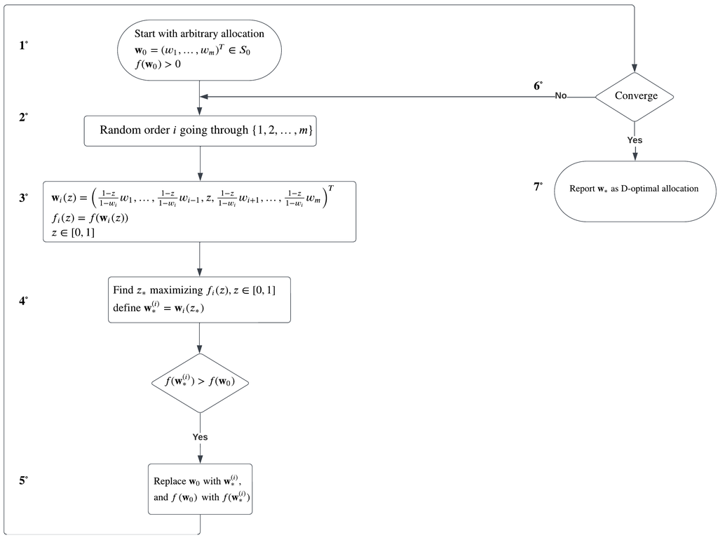

Figure 1: The framework of lift-one algorithm.

In the context of paid research studies, budgetary limitations often necessitate the selection of a subset of participants. We consider the sampling of $n$ subjects from a larger population of $N$, where $n < N$. A typical constraint in such studies is $n_i \leq N_i$, where $N_i$ represents the number of available subjects from the $i$th experimental setting group. This effectively places an upper bound on the sample size for each subgroup (or stratum), ensuring the sampling process does not overdraw from any subgroup. Additional constraints may include $n_1 + n_2 + n_3 + n_4 \leq 392$ (see the MLM example in Section 3.2), $4n_1 \geq n_3$ (see Example S2.2 in Supplementary Material Section S2), etc. The constrained lift-one algorithm seeks the approximate allocation ${\mathbf w}$ that maximizes $|{\mathbf F}({\mathbf w})|$, on a collection of feasible approximate allocations $S \subseteq S_0$ where
$$S_0 := \{(w_1, \ldots, w_m)^\top \in \mathbb{R}^m
\mid w_i \geq 0, i=1, \ldots, m; \sum_{i=1}^m w_i = 1\}.$$
The set $S$ is presumed to be either a closed convex set or a finite union of closed convex sets. The framework of the constrained lift-one algorithm is provided in Figure 2. The details of the algorithm can be found in Algorithm 1 of Huang, Tong, and Yang (2025). In the constrained lift-one algorithm, the search for the optimal lift-one weight $z$ in step $3^\circ$ of Figure 2 is confined within the interval of $[r_{i1}, r_{i2}]$ (Example S2.2 in Supplementary Material Section S2 and Section S.3 in (Huang, Tong, and Yang 2025) for details of finding $[r_{i1}, r_{i2}]$). To ensure that the resulting allocation is D-optimal, two additional decision steps, labeled steps $7^\circ$ and $8^\circ$, are incorporated into the algorithm. The reported allocation in step $10^\circ$ is the constrained D-optimal approximate allocation for the study. To illustrate the difference between the lift-one algorithm and the constrained lift-one algorithm, we provide examples in Supplementary Material Section S2.

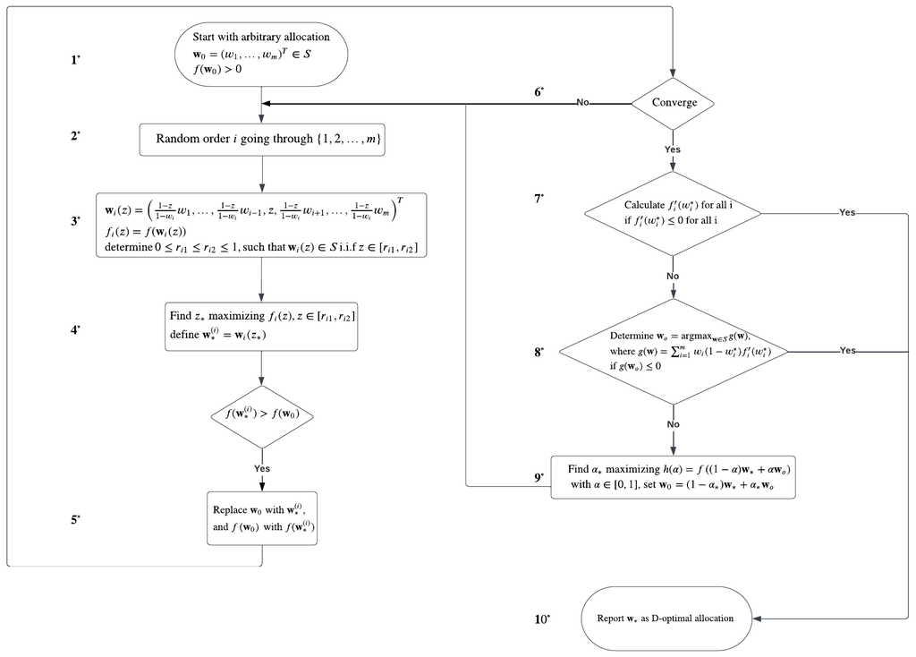

Figure 2: The framework of constrained lift-one algorithm.

Upon obtaining the approximate allocation, we may employ the constrained approximate to exact allocation algorithm outlined in Figure 3 for the conversion of a real-valued approximate allocation to an integer-valued exact allocation. The full details of the algorithm are in Algorithm 2 of Huang, Tong, and Yang (2025). The algorithm begins by assigning a floor integer value to all subgroups $n_i = \lfloor Nw_i\rfloor$. Subsequently, each remaining subject is added to the corresponding group in a manner that maximizes the determinant of the Fisher information matrix. This transformation provides a more pragmatic application in the actual sampling process within paid research studies.

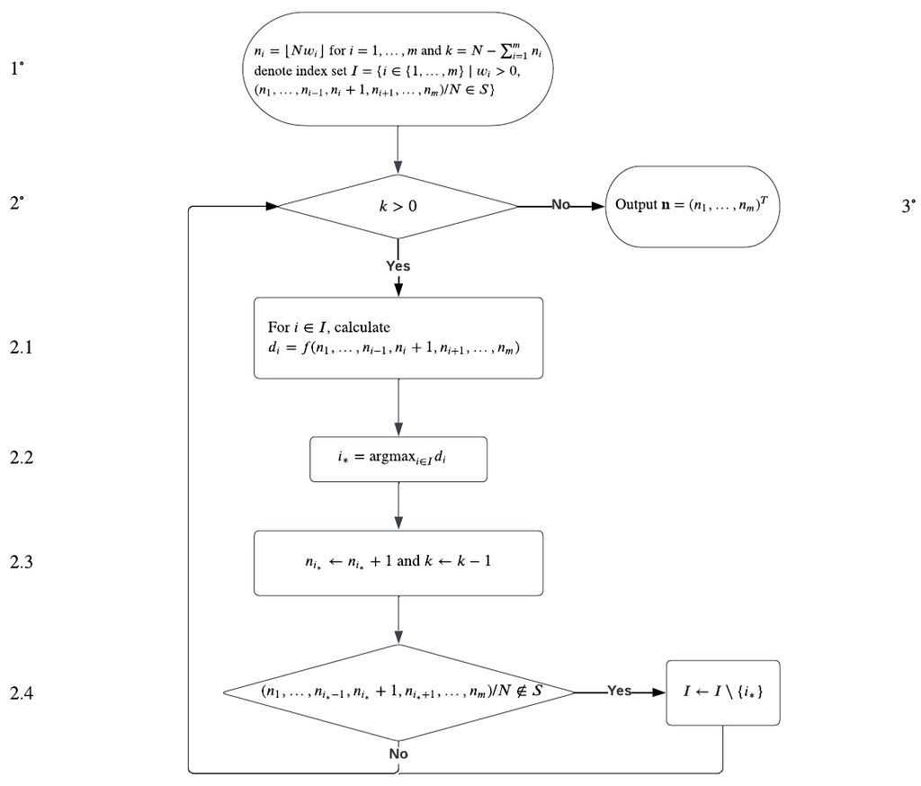

Figure 3: The framework of constrained approximate to exact algorithm.

The calculation of the Fisher information matrix $\mathbf{F}$ and the subsequent maximization of its determinant $|\mathbf{F}|$ are key steps in both the constrained and original (unconstrained) lift-one algorithms. The theoretical details and functions for the computation of $\mathbf{F}$ are provided in Sections 2.2 and Section 2.3.

### Fisher information for generalized linear models

The generalized linear model (GLM) broadens the scope of the traditional linear model. In the standard approach, the response variable is expected to change in direct proportion to the covariate. Yet, this isn’t always a practical assumption. Take binary outcomes, for instance, the classic linear model falls short here. Similarly, it’s unsuitable for positive-only data like count data. (Nelder and Wedderburn 1972) expanded the model to accommodate a wider range of applications.

For a GLM, we assume that response variables $Y_1, \dots, Y_n$ are independent and from the exponential family. Then we have (Dobson and Barnett 2018; McCullagh and Nelder 1989)
$$E(Y_i \mid \mathbf X_i) =
\mu_i,\quad g(\mu_i)=\eta_i=\mathbf X_i^\top \boldsymbol \beta$$
where $g$ is a link function, $\boldsymbol \beta = (\beta_1, \beta_2,\dots, \beta_p)^\top$ is the parameter vector of interest, and $\mu_i$ is the conditional expectation of response $Y_i$ given predictors $\mathbf X_i = \mathbf h(\mathbf x_i) = (h_1(\mathbf x_i),\dots, h_p(\mathbf x_i))^\top$, where $i = 1, \dots, n$ with known and deterministic predictor functions $\mathbf h = (h_1, \dots, h_p)^\top$. There are various link functions that could be used, for example, logit link $\eta_i = \log\frac{\mu_i}{1-\mu_i}$; probit link $\eta_i = \Phi^{-1}(\mu_i)$, where $\Phi(\cdot)$ is the normal cumulative distribution function; and complementary log-log link $\eta_i = \log\{-\log(1-\mu_i)\}$. Regular linear models can be considered as GLMs with the identity link function and normal responses. Suppose we have a design with $m$ design points $\mathbf x_1, \dots, \mathbf x_m$ that has an exact allocation $(n_1,\dots,n_m)$ where $\sum_i n_i = n$ and corresponding approximate allocation $(w_1,\dots,w_m)=(\frac{n_1}{n},\dots,\frac{n_m}{n})$. The Fisher information matrix $\mathbf F$ under GLMs can be written as (McCullagh and Nelder 1989; Khuri et al. 2006; Stufken and Yang 2012; J. Yang, Mandal, and Majumdar 2016):
$$\label{eq:FisherGLM}
\mathbf F = n \mathbf X^\top \mathbf W \mathbf X = n\sum_{i=1}^m w_i
\nu_i {\mathbf X}_i{\mathbf X}_i^\top (\#eq:FisherGLM)$$
where $\mathbf X = (\mathbf X_1, \dots, \mathbf X_m)^\top$ is the $m\times p$ design matrix with $\mathbf X_i = \mathbf h(\mathbf x_i)$, $\mathbf W = \text{diag}\{w_1\nu_1,$ $\dots, w_m\nu_m\}$ is a diagonal matrix with $\nu_i = \frac{1}{\text{Var}(Y_i)} (\frac{\partial \mu_i}{\partial \eta_i})^2$. Here, $\nu_i$ represents how much information the design point $\mathbf x_i$ contains. The explicit formats of $\nu_i$ with different response distributions and link functions can be found in Table 5 of the Supplementary Material of (Huang, Tong, and Yang 2025). To calculate the Fisher information matrix $\mathbf{F}$ given the approximate allocation $\mathbf{w}$, we may use the `F_func_GLM()` function in the [**CDsampling**](https://CRAN.R-project.org/package=CDsampling) package. Additionally, the `W_func_GLM()` function can be used to find the diagonal elements of the matrix $\mathbf{W}$ in the Fisher information matrix @ref(eq:FisherGLM) of GLM. An example of finding the Fisher information matrix for GLM is provided in Example S1.1 of Supplementary Material.

### Fisher information for multinomial logistic model

The multinomial logistic model (MLM) is an extension of GLM aiming to manage responses that fall into multiple categories, such as rating scales and disease severity levels (Agresti 2013).

We assume that the responses $\mathbf Y_i = (Y_{i1},\dots,Y_{iJ})$ follow a multinomial distribution with probabilities $(\pi_{i1}, \dots, \pi_{iJ})$, where $\pi_{ij} = \text{P}(Y_i=j \mid {\mathbf x}_i)$, $Y_i \in \{1, \ldots, J\}$ is the $i$th original categorical response, $j = 1,\dots, J$, and $\sum_j \pi_{ij} = 1$. If the response variables are nominal, in other words, there is no natural ordering among different levels, a commonly used MLM is the baseline-category logit model with the $J$th level selected as the baseline category. If the response variable is ordinal, that is, we have a natural ordering of response levels, there are three commonly used MLMs in the literature: cumulative logit model, adjacent logit model, and continuation-ratio logit model (Bu, Majumdar, and Yang 2020; Dousti Mousavi, Aldirawi, and Yang 2023; Wang and Yang, n.d.).

In addition to different logit models, the proportional odds (po) assumption is an important concept in MLMs. The po assumption is a parsimonious model assumption, where a model simultaneously uses all $J-1$ logits in a single model with the same coefficients. This means the covariate effect is constant on the odds ratio among different response levels. When the assumption doesn’t hold, the model is referred to as a non-proportional odds (npo) model and has more parameters in it. When the assumption only holds for part of the parameters, the model is referred to as a partial proportional odds (ppo) model. Commonly used multinomial logit models with po, npo, or ppo assumptions can be summarized in a unified matrix form (Glonek and McCullagh 1995; Zocchi and Atkinson 1999; Bu, Majumdar, and Yang 2020):
$$\mathbf C^\top \log(\mathbf
L \boldsymbol \pi_i) = \mathbf X_i \boldsymbol \theta$$
where
$$\mathbf C^\top = \begin{pmatrix}
\mathbf I_{J-1} & -\mathbf I_{J-1} & \mathbf 0^\top_{J-1} \\
\mathbf 0^\top_{J-1} & \mathbf 0_{J-1} & 1 \\
\end{pmatrix}$$
is a $J \times (2J-1)$ constant matrix, $\mathbf L$ is a $(2J-1)\times J$ constant matrix with different formats among the four different multinomial logit models, and $\boldsymbol \pi_i = (\pi_{i1},\dots,\pi_{iJ})^\top$. The model matrix $\mathbf X_i$ is defined in general as
$$\mathbf X_i = \begin{pmatrix}
\mathbf h_1^\top(\mathbf x_i)& & & \mathbf
h_c^\top(\mathbf x_i)\\
& \ddots & & \vdots\\
& & \mathbf h_{J-1}^\top (\mathbf x_i) & \mathbf
h_{c}^\top (\mathbf x_i)\\
\mathbf 0^\top_{p_1} & \dots & \mathbf 0^\top_{p_{J-1}}
& \mathbf 0^\top_{p_c}
\end{pmatrix}_{J \times p}$$
and the parameter $\boldsymbol \theta=(\boldsymbol\beta_1^\top, \dots, \boldsymbol \beta^\top_{J-1}, \boldsymbol\zeta^\top)^\top$ consists of $p=p_1 + \dots + p_{J-1}+p_c$ unknown parameters. Here $\mathbf h_j^\top(\cdot) = (h_{j1}(\cdot),\dots, h_{jp_j}(\cdot))$ are known functions to determine $p_j$ predictors associated with unknown parameters $\boldsymbol \beta_j = (\beta_{j1}, \dots, \beta_{jp_{j}})^\top$ in $j$th response category, and $\mathbf h_c^\top(\cdot) = (h_{1}(\cdot),\dots, h_{p_c}(\cdot))$ are known functions to determine $p_c$ predictors associated with proportional odds parameters $\boldsymbol \zeta = (\zeta_1, \dots, \zeta_{p_c})^\top$. If $\mathbf h_j^\top(\mathbf x_i)\equiv1$, the model is a po model; if $\mathbf h_c^\top(\mathbf x_i)\equiv0$, the model is an npo model.

According to Theorem 2.1 in (Bu, Majumdar, and Yang 2020), the Fisher information matrix under a multinomial logistic regression model with independent observations can be written as
$$\label{eq:F_sum}
\mathbf F = \sum_{i=1}^m n_i \mathbf F_i (\#eq:F-sum)$$
where $\mathbf F_i = (\frac{\partial{\boldsymbol\pi_i}}{\partial{\boldsymbol \theta^\top}})^\top \text{diag}(\boldsymbol \pi_i)^{-1}\frac{\partial \boldsymbol \pi_i}{\partial \boldsymbol \theta^\top}$ with $\frac{\partial \boldsymbol \pi_i}{\partial \boldsymbol \theta^\top} = (\mathbf C^\top \mathbf D_i^{-1} \mathbf L)^{-1}$ and $\mathbf D_i = \text{diag}(\mathbf L \boldsymbol \pi_i)$. Explicit forms of $(\mathbf C^\top \mathbf D_i^{-1} \mathbf L)^{-1}$ can be found in Section S.3 of the Supplementary Material of (Bu, Majumdar, and Yang 2020). To calculate the Fisher information matrix $\mathbf F$ for the MLM, one may use the function `F_func_MLM()` in the [**CDsampling**](https://CRAN.R-project.org/package=CDsampling) package. An example of finding the Fisher information matrix for MLM is provided in Example S1.2 of the Supplementary Material.

## Examples

The methods described in Section 2 are implemented in the proposed R package [**CDsampling**](https://CRAN.R-project.org/package=CDsampling). The [**CDsampling**](https://CRAN.R-project.org/package=CDsampling) package comprises $16$ functions, as detailed in Table 1. The primary functions of the [**CDsampling**](https://CRAN.R-project.org/package=CDsampling) package are `liftone_constrained_GLM()` and `liftone_constrained_MLM()`. Additionally, the package includes the original (unconstrained) lift-one algorithm for general experimental designs, accessible via the `liftone_GLM()` and `liftone_MLM()` functions. Two datasets `trial_data` and `trauma_data` are provided for illustration purposes.

(#tab:T1) Functions and corresponding usages in the [**CDsampling**](https://CRAN.R-project.org/package=CDsampling) package.

|  | Usage | Function |
| --- | --- | --- |
| Model | Calculating $\mathbf W$ matrix diagonal elements of generalized linear model (see Section 2.2); providing input for function `liftone_GLM()` and `liftone_constrained_GLM()`. | `W_func_GLM()` |
|  | Calculating Fisher information matrix and its determinant of generalized linear model (see Example S1.1 in Supplementary Material). | `F_func_GLM()`, `Fdet_func_GLM()` |
|  | Calculating Fisher information matrix of multinomial logit model at a specific design point (see Section 2.3); using as input of `liftone_MLM()` and `liftone_constrained_MLM()`. | `Fi_func_MLM()` |
|  | Calculating Fisher information matrix and its determinant of multinomial logit model (see Example S1.2 in Supplementary Material). | `F_func_MLM()`, `Fdet_func_MLM()` |
|  | Using in `approxtoexact_constrained_func()` to find constrained uniform exact allocation. | `Fdet_func_unif()` |
| Sampling | Finding unconstrained D-optimal approximate allocation for generalized linear model and multinomial logit model (see Section S2 in Supplementary Material). | `liftone_GLM()`, `liftone_MLM()` |
|  | Finding constrained D-optimal approximate allocation for generalized linear model and multinomial logit model (see Section 3). | `liftone_constrained_GLM()`, `liftone_constrained_MLM()` |
|  | Transferring approximate allocation to exact allocation (see Section 3). | `approxtoexact_constrained_func()` |
|  | Finding constrained uniform exact allocation for bounded constraint (see Section 3.1). | `approxtoexact_func()` `bounded_uniform()` |
| Example Specific | Finding $I$ set for exact allocation conversion in `trial_data` and `trauma_data` examples (see Section 3 and Section S4 in Supplementary Material). | `iset_func_trauma()`, `iset_func_trial()` |

In the remainder of this section, we present two examples to illustrate the usage of the [**CDsampling**](https://CRAN.R-project.org/package=CDsampling) package for sampling problems in paid research studies, using datasets provided by [**CDsampling**](https://CRAN.R-project.org/package=CDsampling). All results in this section were generated using R version 4.3.2 on a macOS Sonoma 14.6.1 system.

### Applications in paid research study: $\tt trial\_data$ example

The `trial_data` dataset is simulated data for a toy example of paid research studies. This study includes a cohort of $500$ patients for a clinical trial, with gender and age as stratification factors. A logistic regression model incorporates these factors as covariates: `gender` (coded as $0$ for female and $1$ for male) and `age` (coded as two dummy variables $age\_1$ and $age\_2$ with $(age\_1, age\_2) = (0, 0)$ for age group $18\sim25$; $(1, 0)$ for age group $26\sim64$, and $(0, 1)$ for age group $65$ and above). For simplicity, the study assumes binary gender options and a tripartite age categorization. In total, there are $m=6$ combinations of covariate factors. In practice, non-binary gender options and a “prefer not to answer” choice may be included to respect gender diversity and protect patient confidentiality. The response $Y$ denotes the treatment’s efficacy ($0$ indicating ineffectiveness, $1$ indicating effectiveness). The data is generated by the logistic regression model
$$\label{eq:triallogisticmodel}
{\rm logit} \{P(Y_{ij}=1 \mid x_{gender\_i}, x_{age\_1i}, x_{age\_2i})\}
= \beta_0 + \beta_1 x_{gender\_i} + \beta_{21} x_{age\_1i} + \beta_{22}
x_{age\_2i} (\#eq:triallogisticmodel)$$
with $(\beta_0, \beta_1, \beta_{21}, \beta_{22}) = (0,3,3,3)$, where $i=1, \ldots, 6$ stands for the $i$th covariate combination, and $j = 1, \ldots, N_i$ is an index of patients who fall into the $i$th covariate combination or sampling subgroups. Figure 4 illustrates the distribution of treatment efficacy across different `gender` and `age` groups.

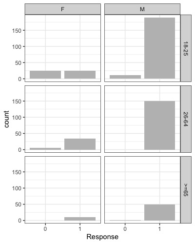

Figure 4: The number of patients from different gender (F, M) and age groups ($18-25$, $26-64$, and $\ge 65$) and their responses ($0$ indicating ineffectiveness, $1$ indicating effectiveness) to treatment in `trial_data` of [**CDsampling**](https://CRAN.R-project.org/package=CDsampling) package.

In this example, it is posited that a sample of $n=200$ participants is desired from the population of $N=500$ volunteers due to budget constraints. The objective is to examine the variation in efficacy rates across gender and age demographics. Should a pilot study or relevant literature provide approximate values for the model parameters, a constrained lift-one algorithm may be employed to find a locally D-optimal design. Conversely, if only partial parameter information is available, the expectation can be deduced from some prior distributions, and the constrained lift-one algorithm can be utilized to determine an EW D-optimal allocation (substituting $\mathbf W$ in the Fisher information matrix @ref(eq:FisherGLM) with $E(\mathbf W)$).

There are $m=6$ design points, corresponding to gender and age group combinations $(x_{gender\_i},$ $x_{age\_1i}, x_{age\_2i}) = (0,0,0)$, $(0,1,0)$, $(0,0,1)$, $(1,0,0)$, $(1,1,0)$, and $(1,0,1)$, respectively. The numbers of available volunteers in the six categories are $(N_1, N_2, \ldots, N_6) = (50, 40, 10,$ $200, 150, 50)$. Our goal is to find the constrained D-optimal allocation $(w_1, w_2, \dots, w_6)$ in the set of all feasible allocations $S = \{(w_1, \ldots,$ $w_m)^T \in S_0 \mid n w_i \leq N_i, i=1, \ldots, m\}$.

We consider the logistic regression model @ref(eq:triallogisticmodel), to find the locally D-optimal design, we assume, for illustrative purposes, that the model parameters $(\beta_0, \beta_{1}, \beta_{21}, \beta_{22})$ $=(0,3,3,3)$. We may define the parameters and the model matrix as follows. Subsequently, we find the $\mathbf W$ matrix in Equation @ref(eq:FisherGLM) for the Fisher information matrix $\mathbf F$.

```r
> beta = c(0, 3, 3, 3) #coefficients
> #design matrix
> X=matrix(data=c(1,0,0,0,1,0,1,0,1,0,0,1,1,1,0,0,1,1,1,0,1,1,0,1), ncol=4, byrow=TRUE)
> W=W_func_GLM(X=X, b=beta, link="logit") #find W as input of constrained liftone
```

To define the number of design points, sample size, and constraints with $S$, we use the following R codes (see Section S3 in the Supplementary Material of (Huang, Tong, and Yang 2025) for details on finding $r_{i1}$ and $r_{i2}$ in step 3 of the constrained liftone algorithm in Figure 2):

```r
> rc = c(50, 40, 10, 200, 150, 50)/200 #available volunteers/sample size
> m = 6 #design points

> g.con = matrix(0,nrow=(2*m+1), ncol=m) #constraints
> g.con[1,] = rep(1, m)
> g.con[2:(m+1),] = diag(m)
> g.con[(m+2):(2*m+1), ] = diag(m)
> g.dir = c("==", rep("<=", m), rep(">=", m)) #direction
> g.rhs = c(1, rc, rep(0, m)) #righ-hand side

> #lower bound in step 3 of constrained liftone
> lower.bound=function(i, w){
+   rc = c(50, 40, 10, 200, 150, 50)/200
+   m=length(w)
+   temp = rep(0,m)
+   temp[w>0]=1-pmin(1,rc[w>0])*(1-w[i])/w[w>0];
+   temp[i]=0;
+   max(0,temp);
+   }

> #upper bound in step 3 of constrained liftone
> upper.bound=function(i, w){
+   rc = c(50, 40, 10, 200, 150, 50)/200
+   min(1,rc[i]);
+   }
```

To identify the subgroups of the output D-optimal allocations, we may add an optional label for each of the $m=6$ covariatres combination or subgroups as “F, 18-25”, “F, 26-64”, “F, >=65”, “M, 18-2”, “M, 26-6”, “M, >=65” using the following codes:

```r
> label = c("F, 18-25", "F, 26-64", "F, >=65", "M, 18-25", "M, 26-64", "M, >=65")
```

Then, we run the constrained lift-one algorithm with to find the constrained D-optimal approximate allocation.

```r
> set.seed(092)
> approximate_design = liftone_constrained_GLM(X=X, W=W, g.con=g.con, g.dir=g.dir,
+ g.rhs=g.rhs, lower.bound=lower.bound, upper.bound=upper.bound, reltol=1e-10,
+ maxit=100, random=TRUE, nram=4, w00=NULL, epsilon=1e-8, label=label)
```

The design output is presented below:

```r
> print(approximate_design)

Optimal Sampling Results:
================================================================================
Optimal approximate allocation:
   F, 18-25 F, 26-64 F, >=65 M, 18-25 M, 26-64 M, >=65
w  0.25     0.2      0.05    0.5      0.0      0.0
w0 0.25     0.0      0.05    0.7      0.0      0.0
--------------------------------------------------------------------------------
maximum :
2.8813e-08
--------------------------------------------------------------------------------
convergence :
TRUE
--------------------------------------------------------------------------------
itmax :
9.0
--------------------------------------------------------------------------------
deriv.ans :
0.0, 3.6017e-08, 4.8528e-07, -1.1525e-07, -1.0310e-07, -7.9507e-08
--------------------------------------------------------------------------------
gmax :
0.0
--------------------------------------------------------------------------------
reason :
"gmax <= 0"
--------------------------------------------------------------------------------
```

The output includes several key components:

- $\mathbf w$: reports the D-optimal approximate allocation.
- $\mathbf w_0$: reports the random initial approximate allocation used to initialize optimization.
- **maximum**: reports the maximum determinant of Fisher information matrix.
- **reason**: reports the termination criterion for the constrained lift-one algorithm including either “all derivative $\le$ 0” or “gmax $\le$ 0”, which corresponds to step $7^\circ$ and step $8^\circ$ in the constrained lift-one algorithm in Figure 2.

In practical terms, exact allocations are more beneficial. One may use the constrained approximate to exact allocation algorithm depicted in Figure 3, which is implemented as the function.

```r
> exact_design = approxtoexact_constrained_func(n=200, w=approximate_design$w, m=6,
+ beta=beta, link='logit', X=X, Fdet_func=Fdet_func_GLM, iset_func=iset_func_trial,
+ label=label)
> print(exact_design)

Optimal Sampling Results:
================================================================================
Optimal exact allocation:
                F, 18-25 F, 26-64 F, >=65 M, 18-25 M, 26-64 M, >=65
allocation      50.0     40.0     10.0    100.0    0.0      0.0
allocation.real 0.25     0.2      0.05    0.5      0.0      0.0
--------------------------------------------------------------------------------
det.maximum :
46.1012
--------------------------------------------------------------------------------
```

The output provides three key components for the sampling results:

- **allocation**: reports the exact allocation of D-optimal sampling, specifying the number of subjects to sample from each subgroup.
- **allocation.real**: reports the real-number approximate allocation used prior to integer conversion.
- **det.maximum**: reports the maximum determinant of the Fisher information matrix by the optimal design.

In this example, the D-optimal exact allocation is to sample $50$ subjects from the “female, $18-25$” subgroup, $40$ subjects from the “female, $26-64$” subgroup, $10$ subjects from the “female, $\ge 65$” subgroup, and $100$ subjects from the “male, $18-25$” subgroup. Such a design may not explore all the design space and may lead to extreme design cases. In practice, allocating some subjects to the omitted subgroups “male, $26-64$” and “male, $\ge 65$” could improve robustness and reduce the risk of overfitting.